# eReuse.org Whitepaper

The Circular Economy of Digital Devices

$^1$Universitat Politècnica de Catalunya David Franquesa 1[^1], Leandro Navarro 1$^1$, y todos los que faltan!

2022-02-21

# Abstract

The eReuse.org federation develops a set of tools and methodologies to bootstrap reuse of digital devices and account its contribution to the circular economy. The intended impact is to extend device lifetime and increase proper recycling at the end of the useful lifetime. In this whitepaper we present the federation, the tecnological roadmap and use cases that create value to consumers, refurbishers and recyclers. In the roadmap we present the conditions and capabilities required for verify traceability and impact accounting while while preserving privacy of consumers and businesses. The aim is to make replication easy for other regions and allow the interoperation with others systems with the purpose of make reuse/recycling and tech industry impact accountable. Ultimately empowering consumers to choose reparable, reusable and durable devices.

**Objectivo:**

- El del whitepaper es principalmente un documento introductorio para externos aunque también puede servir para colaboradores internos (proyectistas,…) que quieren iniciarse.
- Un white paper es declarativo: como está, que debes entender para poder usar/participar,… [A la tesi expliques els perques i ho valides. La lógica, es un coneixment. Quina validació fas, dicussió.]
- Explicar los casos de uso y roadmap tecnológico necesario para llevarlos a cabo (que tenemos hoy y que queremos para el futuro)

**Capítulos:**

**capítulo I: Introducción.**

Que es eReuse, que objetivos tiene, quien forma parte

**capítulo II: Conceptos.**

A qui queremos explicar la visión de eReuse de la economía circular

**capítulo III: Impact and outcomes**

Descripción del impacto y outcomes.

**Capitol IV: Use cases.**

Poder conocer las preguntas generales y la útilidad. Expertos de EC puedan saber de que trata sin ir al detalle o tener que compartir la propuesta.

Descripción de los use cases pero no llegar a explicar la implementación/propuesta/detalle. Por ejemplo la figura 4.1 potser es massa detallada. POsar-ho un nou apartat al final: on estem i detall.

Importante poder vislumbrar que building blocks, conditions or capabilities van a ser necesarias para poder implementarlo

Mirar document sobre w3i: Explicar les funcionalitats/requeriments i casos d’us.

**capitulo V: Roadmap: building blocks, conditions or capabilities**

Asegurar la coherencia entre Capito anterior de casos de uso con este (que building blocks, conditions or capabilities) tal que creemos que són necesarios para poder responder a nuestros casos de uso.

Explicar a alto nivel lo que se necesita pero no explciar el como (implementación ejemplo como construimos el hardware id o el product passport).

Information systems and tools Circular economy accountability Incentives for circularity

**capitulo VI: Technology**

Por ahora un listado de los repositorios que tenemos propios y legacy.

# Introduction

Digital devices such as desktops, laptops and mobiles should be affordable and does not harm people and the environment. The principle we apply is try to keep in use devices for as long as possible and to ensure their final recycling. Our approach is to empower field actors such as repairers, refurbishers and recyclers as well as the ecosystems they form at local level (circuits). Together members and partners provides with a new mindset and an open-source tech to enhance reuse and make tech industry impact accountable.

## Collaboration to avoid premature recycling

Ereuse.org is a federation of organisations that cooperate to promote the reuse of electronics and to avoid its premature recycling. We are not an organisation but rather a federation of organisations collaborating with the aim to help to sustain and grow ecosystems that increase reuse/recycling.

We motivate and promote the emergence of collaborative and circular economy ecosystems that increase reuse/recycling and account final recycling with a verifiable accountability of impact.

We have brought together a federation of repairers, refurbishers (the local companies that collect used devices from governments and companies to repair, distribute in the second hand market) and recyclers. Most of these are social economy organizations that refurbish, recycle and distribute second-hand devices such as mobiles, laptops or desktop computers.

eReuse has three categories of partnerships which we name under strategic, innovation and research:

- Strategic partners are organizations that promote social awareness about the social and environmental impact of electronics, social economy, right to repair, zero waste, digital inclusion, circular economy, social economy, fair electronics and the right to repair.
- Innovation partners are startups and innovators that bring their technologies and solutions the the transition to circular and accountable.
- Research partners are universities and research centres.

Finaly eReuse has supporters that are public administrations, city councils and companies that collaborate with partners and impact accountable members.

Together with members, partners and supporters we accelerate the transition towards a circular economy of electronics that avoids premature recycling.

The Ereuse.org cluster was launched in 2015 under the coordination of Pangea.org, a private, independent non-profit organization founded in 1993 to promote the strategic and environmental use of ICT.

### Why Electronics are not affordable and not sustainable

Electronics, including computers, tablets or smartphones is increasing exponentially and is one the biggest and most environmentally damaging industries. Raw materials are crucial for electronics, are non renewable, and cause conflicts and wars. Electronic products involve one of the highest CO2 footprint. Electronic industry workers cry for decent work, and final products, are neither affordable for all people nor sustainable for the planet, with only 20% of electronic waste properly collected and recyled.

The main problem is that the consumption model of digital devices is non-circular, non-resilient and non-affordable. Governments and companies buy new hardware every 3-6 or less years guided by financial reasons (depreciation can only be accounted for over 5 years) not sustainability-driven. The way they dispose of old hardware is not sustainable, or responsible, and often guided only by economic criteria. Furthermore, manufacturers do not build for durability.

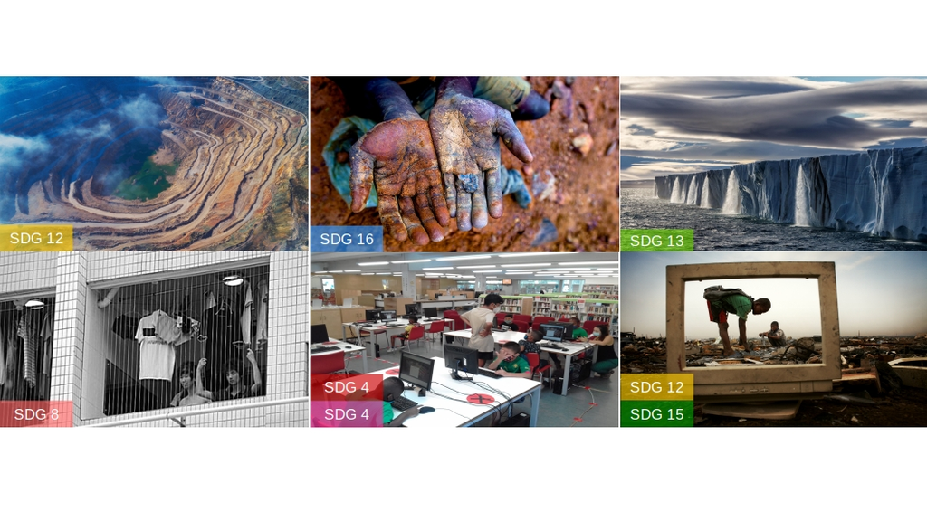

ICT impacts

### What society can do today

Most devices from business and public administration are discarded when considered amortized, and although they still have a value for use and are suitable for reuse, they are scrapped (recycled), or illegally exported to other countries via informal reuse circuits. The positive aspects of reuse are well understood, reuse effectively contributes to develop a circular economy, strengthen the creation of local employment, prevent the generation of waste, and reduce the digital divide. However, why is it such a minority practice? When companies, governments or individuals need to get rid of their computers and digital devices to have a new life (reuse), they don’t know where to turn. This results in most Electric and Electronic Equipment (EEE) being recycled even though the explicit demand for reuse.

### What does our members and partners

Members, partners and supporters cooperate to help to sustain and grow ecosystems that increase reuse and recycling and together we build a new mindset and open-source tech to make reuse/recycling tech industry more durable, reusable, repairable and impact accountable. The coalition of members and partners bring together the skills, training and open technologies necessary to help sustain and grow federated and autonomous platforms that optimize refurbishment, ensure quality of second hand electronics products and bring management in the reverse supply chain to incentivitize reused devices are ultimately recycled and impact accountable.

## Stardarize, coordinate requirements and bootstrap reuse

### Coordinate a roadmap of resources to increase and comunicate reuse and recycling

The challenge is to provide resources to optimize reuse and make it impact accountable. This information creates trust when it is shared with device suppliers, refurbishers, consumers and a data-commons for measuring circularity of devices. Resources can be refurbishment tools, inventory management, product passport traceability systems, self-asses and self-certify mechanisms for quality and circularity standards, good practices and case studies. The information generated is verifyable because the usage of digital twin technologies in sincronization with distributed ledgers. Together we build a new mindset and open-source tech to make reuse/recycling tech industry more durable, reusable, repairable and impact accountable.

### Bootstraping reuse and recycling ecosystems to extend the lifetime of digital devices

The coalition of members and partners exchange know-how, build connections and bring together the skills and training to help sustain and grow federated and autonomous ecosystems that optimize refurbishment, ensure quality of second hand electronics products and bring management in the reverse supply chain to incentivitize reused devices are ultimately recycled and impact accountable. We coordinate and promote the creation of local circuits where several entities intercooperate under different roles to capture, refurbish and redistribute devices with a quality certificate to, among others, citizens affected by digital inequality.

## Members, partners and circuits

Ereuse.org is a federation of organisations dedicated to the transition to collaborative and circular consumption of electronics. Our federated members are local groups, business and organizations with the goal to extend the lifetime of products through repair, refurbish, retail and in general reuse.

### Refurbishers and Resellers

#### Solidanca.cat

Solidança is a nonprofit organization created in 1997 and dedicated to the professional training and labor insertion of people in social vulnerability. To this end, in 2006, created a company Solidança labor insertion -Solidança Labor EI – which offers services in the environmental sector, specifically in the management and revaluation of certain waste fractions.

#### Reutilitza.upc.edu

The Universitat Politècnica de Catalunya (Spain) has a service-learning reuse program (reutilitza.upc.edu). Involves more than 500 students every year on tasks around repairing and refurbishing computers. Up to December 2016, more than 2000 computers were repaired, installed and handed over to 140 solidarity projects around the world.

#### Pontsolidari.org

The Banc de Recursos Foundation located in Barcelona, is focused on reutilization and redistribution of goods at both, national and international level and on development aid projects. Through the on line platform www.pontsolidari.org , used computers coming from donations of business companies, are being reused in social organizations and charities.

#### Trinijove.org

Trinijove facilitate entrepreneurship of youth in risk of exclusion an new business models such as sharing and leasing schemes for products. Trinijove is a private foundation based on Catalonia (Spain) that aims its efforts in the education of people with difficulties and helps them in the task of finding a job.

#### Andromines.net

Andromines is a nonprofit organization that since 1993 works for a more just and equitable society, by denouncing and fighting social exclusion and welcoming people marginalized labor. Its project ‘Recycle PC’ is based on carrying out the recovery and recycling of WEEE (Waste Electrical and Electronic Equipment and) Line Gray (computers, monitors, printers and other computer accessories).

#### Reciclanet.org

Reciclanet is an Educational, Ecological and Solidarity Association, formed by volunteers. We develop projects for recovery and reuse of computer equipment, and the spread of free software. Our philosophy is based on people, and speaking of sharing, educate and be solidari @. We work since 2000, promoting the sharing and reuse of computers with open source.

#### Elkartenet.eus

Elkartenet is a non-profit educational association and main objective is to carry out educational, associative and commercial revitalization projects supported by tools designed with Free Software and with criteria to fight against the different forms of Digital Divide and favouring Circular Economy.

#### Ieselcalamot.com

The Calamot Institute is a public secondary education compulsory and post-compulsory taught ESO, secondary education to middle and top grade.

TAGS: school, not-for-profit.

#### Labdoo.org

Labdoo is a humanitarian social network joined by people around the world who want to make our planet a better place by providing those in underdeveloped regions (both in the developing and the developed world) a chance at a better education. The goal of the social network is to send unused laptops, ebook readers, tablet-PCs and any device that can be loaded with educational software to needy schools around the world using collaboration and without incurring any economic nor environmental costs.

#### Marianao.net

Marianao Foundation is a nonprofit organization that since 1985 develops socio-educational projects serving the community, to promote the personal and community development in Sant Boi de Llobregat and Baix Llobregat. The Funación is interested in receiving the material does not work and must be repaired.

#### Engrunes.org

Engrunes is a private non-profit enterprise with the purpose to provide people at risk of social exclusion or excluded, support staff, paid work that allows them to rejoin again an active social life and work, using as tools their work and personal effort.

#### Donalo.org

Donalo is a meeting point where companies and people donate digital devices and products to NGOs. The project, based on the accountability of companies according to their standards, is a reformulation of the task did Migrano de Arena Foundation since 2007 and took the name of ‘surplus management’.

#### Abacus.coop

Founded in 1968, Abacus cooperative has more than 850,000 consumer members and 478 business partners. Is a leader in the distribution of books, real educational, cultural and entertainment establishments in Catalonia 45 Catalonia, Valencia, Castellón and Islands. Abacus cooperative is a founding member of the Group clade, the first Catalan cooperative business group.

#### Reutilizak.org

We are a non-profit association that supports the integral development of people at risk and / or social exclusion in the neighborhood of Vallecas in Madrid, since 1986. Encouraging and promoting social participation, especially of juveniles and young people from underprivileged socio-cultural backgrounds, trying to prevent their marginalization from the educational and social process. To promote, carry out and manage social and labor integration projects for people at risk or socially excluded.

#### Ongdreamit.org

DreamIT is an NGO that under the motto “dreams that change the world”, aims to mediate in the adhesion of volunteers and the transfer of technological equipment (Hw and Sw educational) to projects that aim to give an opportunity to the most disadvantaged through education. Our vision is a world in which education is available to the most disadvantaged through technology. Our mission is to transform and make education possible by using technology to empower people in need, focused solely on social change.

#### Fundesplai.org

FUNDACIÓN ESPLAI mission is promoting committed citizenship through social inclusion, social-educational action and a responsible use of ICT, with a special dedication to childhood and youth, all in all within the global aim of encouraging the third sector role in society. They work at local, national and international level developing different projects addressed to different vulnerable groups and designing methodological tools and training materials

#### Hubuntu.es

The NGO Reciclaje Tecnológico was founded in Huesca in 2015 with the aim of reducing the digital divide in the most disadvantaged areas of society. Everything is done through the refurbishing and reuse of digital devices. Digital education and the sustainability of the planet are two of its main objectives.

#### Tau.org.ar

Nodo Tau is a civil association settled in Rosario, Argentina, that since 1995 promotes the use of ICTs in vulnerable groups and social organizations who work for the validity of social, civil, economic and environmental rights. From its experience in the recycling of computer equipment used for the social sector, it has incorporated to the WEEE sector, by managing its own plant of reused, and simultaneously dedicating to the investigation and broadcasting of the issue, by its publications in raee.tau.org.ar.

### Partners

#### Right to Repair Europe

We are a coalition of European organizations active around the cause of repair. Members of the Right to Repair campaign are based in several European countries and represent civil society organisations, repair businesses, community repair initiatives and public institutions. https://repair.eu/our-members/

TAGS: NGO WEB: repair.eu

#### Zero Waste Europe

ZWE brings together and represents the European municipalities that have openly committed to the goal of continuously reducing waste generation and improving waste separate collection and hence redesigning the relationship between people and waste. We are defining a campaign for municipalities with the objective of to increase the number of municipalities willing to promote the circular economy of digital devices. With the help of ZWE we want to find interested municipalities, local zero waste organizations willing to launch local reuse circuits and social reuse centers that repair, refurbish and retail second hand used digital devices.

TAGS: NGO WEB: zerowasteeurope.eu

#### The Restart Project

The Restart Project helps people learn how to repair their broken electronics, and rethink how they consume them in the first place. They run regular Restart Parties where people teach each other how to repair their broken and slow devices – from tablets to toasters, from iPhones to headphones.

TAGS: NGO WEB: therestartproject.org

#### Association for Progressive Communications

The Association for Progressive Comunications is both a network and an organisation. APC members are groups and individuals working in their own countries to empower and support organisations, social movements and individuals in and through the use of information and communication technologies (ICTs) to build strategic communities and initiatives for the purpose of making meaningful contributions to equitable human development, social justice, participatory political processes and environmental sustainability. We have start a global campaign to promote the creation of reuse circuits in municipalities.

TAGS: NGO WEB: apc.org

#### Universitat Politècnica de Catalunya

The Distributed Systems Group at upc.edu performs research on distributed systems and computer networks in the areas of models, algorithms and software for large, complex, dynamic, decentralized systems and applications. We look at large scale and decentralized community networks and community clouds, economics oriented distributed systems, and resource allocation mechanisms. Activities are around the design, modelling and evaluation of systems through modelling and experimentation in real deployments. Outcomes are system architectures, algorithms, software, regulation and adaptive models, decentralized resource allocation and game-theory based mechanisms. The group consists of four professors and a variable number of PhD and master students.

TAGS: Reearch group  
WEB: [Distributed Systems group](https://dsg.ac.upc.edu/)

#### Usody

Usody is a B2B tracing solution to measure & optimize the circular economy impact of digital devices. Business disposing or selling digital devices such as mobiles, desktops and laptops are not taking advantage of the circular economy and social impact they generate. We anonymous trace the reverse-chain of ownership custody, and report data to assess social and environmental impact of reuse and final recycling, generating trust to enable public administrations and companies to offer their devices for reuse to resellers. However the resellers do not feel comfortable in openly sharing this traceability data. They fear competitors, or they might even be penalized, if one of their devices is not properly recycled at the end of its life. For that reason a privacy-preserving distributed ledger technology (DLT) system is used to ensure trust. We differentiate from others by providing traceability & impacting accounting as a stand-alone service that can be used by existing resellers. Resellers are our partners, not competition, and we enable them to provide impact accounting.

TAGS: IT company  
WEB: usody.com

#### Jamgo

Jamgo is a technological cooperative company based in Barcelona, was born in 2011 with the intention of creating a workspace where values such as transparency, cooperation and internal democracy were prioritized. Workers at the cooperative are at the same time partners of the company, which makes Jamgo a completely horizontal work environment were social and solidarity economy and cooperation methodologies are put in practice. Our main objective is to use technology as a tool to promote projects with a positive social impact. Jamgo is also engaged with the values of free software and open data and their contribution to social transformation. Jamgo is main developer of eReuse Android App.

TAGS: IT company, cooperative.  
WEB: jamgo.coop

#### Electronics Watch

Is an organization with the mission to help public sector organisations work together and collaborate with local monitoring partners to protect the labour rights and safety of workers in their electronics supply chains. We’re looking for which data structures are needed to be able to achieve traceability starting at component manufacturing.

TAGS: NGO WEB: [electronicswatch.org](https://electronicswatch.org/en)

#### Sustainable Digital Infraestructure Alliance

The purpose of the Alliance as a professional association is to promote market participants in the field of creating and expanding sustainable digital infrastructure. SDIA is committed to realizing a sustainable digital economy in-line with the UN Sustainable Development Agenda, European Green Deal strategies, Paris Climate Agreement commitments, and other relevant frameworks. The SDIA [Roadmap](https://sdialliance.org/roadmap) to Sustainable Digital Infrastructure.

TAGS: NGO WEB: sdialliance.org

### Circuits

In cities, federated members and city councils collaborate and coordinate in reuse circuits with great effect in creating inclusive jobs, starting or accelerating efficiency and scaling up of local exchange/market of second hand devices. City councils deliver IT retired equipment to local reuse centers that are circular economy impact accountable and collaborate between them to increase reuse and recycling.

#### Background.

Everything started with a “what if we opt for reuse rather than recycling”. In 2014 the Government of Catalonia planned to discard 30,000 computer devices per year until 2019. 92% of the devices were functional and 87% of them were potentially reusable locally by social entities, schools and people digitally excluded. The government wanted to involve all the active reuse centers to do all the work of refurbishing, channeling and tracking these devices. This was the request they made to a research group at the Universitat Politècnica de Catalunya. A few months later the first eReuse.org circuit starts in Catalonia.

#### Collaborative Circuits

The mission of a collaborative Circuit is to promote cooperation between entities in the reuse sector and the responsible, collaborative and circular use of digital devices. In some circuits there is an entity that manage between the City Council and the reuse centers. This manager entity acts as an umbrella of the reuse centers and can be a zero waste or a close the digital divide and that among its principles is to promote collaboration between reuse centers and final users. Figure @ref(fig:ereuseecosystem) explains the role of the manager entity and others participating entities of a circuit.

To make the circuit work, tools, protocols and technology are needed. Thus, open software has been developed that allows entities to manage the registration, inventory and traceability of devices, as well as certify the refurbishment quality. Reuse centers share open data about second-hand computers and their components with the aim of analyzing their life cycle during reuse until final recycling. These data allows to calculate the environmental impact in addition to the hours that have been reused (social impact).

##### Barcelona Circuit

**Manager entity**: Associació Pangea.org

**Reuse centers**: Solidanca.cat, Reutilitza.upc.edu, Pontsolidari.org, Trinijove.org, Andromines.net, Labdoo.org, Engrunes.org, Donalo.org, Fundesplai.org, among others.

In 2017 the Associació Pangea formalized an agreement with Barcelona Activa, as a pilot test, and then with the Barcelona City Council (2018), under which it receives the devices that have fallen into disuse and with de responsability to redistribute to refurbishers from these administrations to share and then distribute them (following circularity performance criteria) with the reuse centers.

These reuse centers can either refurbish and redistribute equipment valid for reuse among final users; or share inventories with other demand-seeking entities; in this case, restricted to ESS, vulnerable schools and families. In the Barcelona circuit, the final users receive on loan, they have usufruct but not the ownership, (Ostrom, 2018) 7, of the equipment. Final users cover the cost of services to make the good reusable, directly or through third parties, such as ESS, public services or Corporate Social Responsibility (CSR) actions.

Recently, and since the emergence of COVID19, from ereuse is also working on green and responsible public procurement with the Social Services of Barcelona City Council to equip public facilities with reused material and to meet prices, that despite being affordable, often cannot be assumed by vulnerable populations. This community strategy created a lot of resilience during confinement and in a context where the linear chain’s own stock chains were severely affected.

Others entities are also integrated into the circuits, which help in the support and improvements of substantial and strategic skills of the final user; entities that provide software and hardware maintenance services; and entities that help increase the functionality of computers with lower performance with the service of desktop virtualization.

##### Madrid Circuit

**Manager entity**: Associació Pangea.org

# Concepts

What eReuse federated members have in commona definition of circular economy.

## The premature recycling of electronics

With more mobile devices than people on earth and powerful companies keen for us to keep purchasing, the successful implementation of the 3Rs (Reduce, Reuse, and Recycle) for electronic devices becomes vitally important. Today, most laptops, desktops and mobile phones are prematurely recycled when they become obsolete or depreciated by companies and public administrations.

When we recycle a device that could be reused we need to manufacture a new computer which is not only damaging to the planet but also excludes those that cannot afford to always buy the latest products.

Limiting premature recycling and promoting reuse is not the final solution to our sustainability problem but it is a way forward. Things improve with less device obsolescence and more cradle-to-cradle.

The reuse of electronic devices such as desktops, laptops or mobile phones is applied to devices that have already been manufactured and are no longer in use (disposed) and will be recycled unless they are “disposed for reuse” by doing any of the following actions refurbish, recondition, repair, upgrade and used again by the same final user or redistributed to other users.

(ref:ereuseloops) Citizen and professional reuse of digital devices.

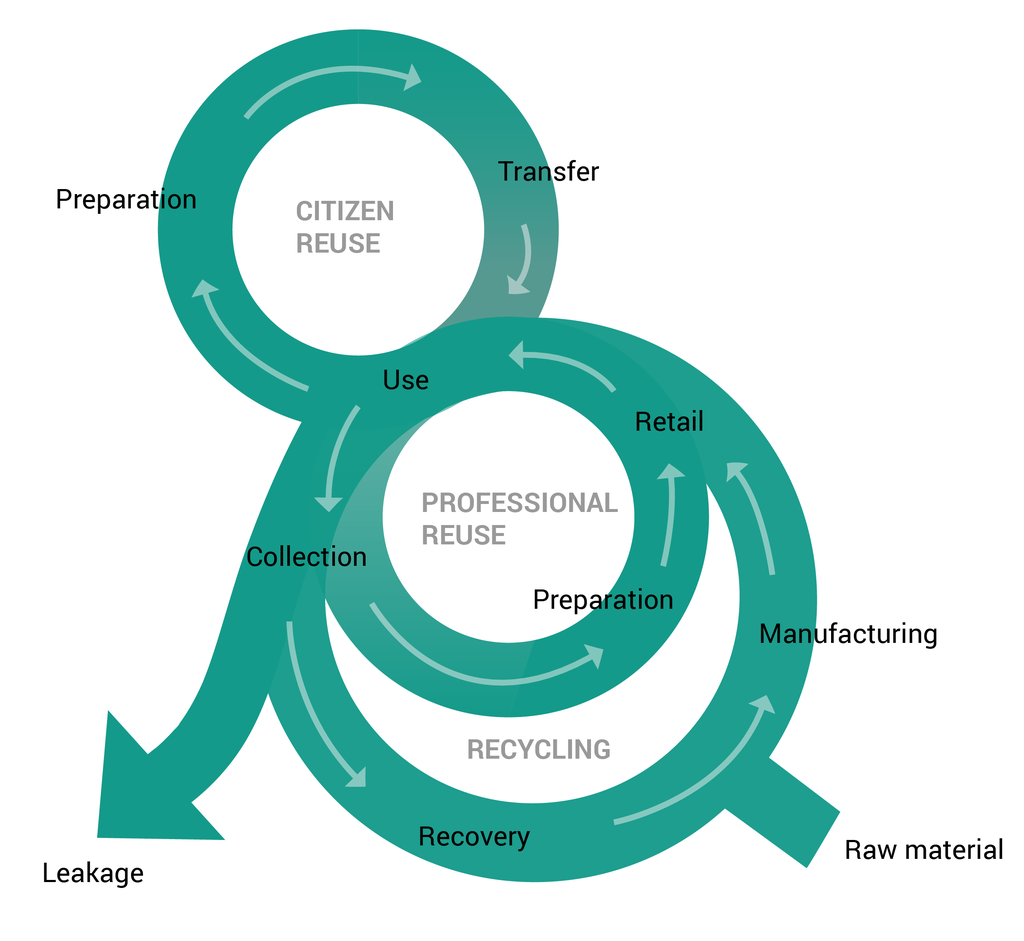

We say a device or component is reusable if it has or may have use value for someone:

- If the use value of the device is high enough, it means that there is somewhere a potential user for that device as it is, and only a basic refurbishing processes is required, such as basic repair, erasing data and restoring the operating system (this is represented as citizen reuse loop in figure @ref(fig:ereuseloops).
- If the use value is too low, its use value can be increased through advanced refurbishing processes: repairing, replacing damaged components and updating/ugrading. This is represented as professional reuse loop in the figure @ref(fig:ereuseloops). In this loop the device is also considered to be electronic waste[^2] and must therefore be treated by a reuse centre authorised to prepare it for reuse.

The reuse process ends when after a few years the device or component reaches disposal for recyling state, which means its use value then, or through potential improvements, does not allow its reuse again. The cycle reach recycling to recover (reuse) raw materials and manufacture new components.

## Circular Economy paradigm and principles

The circular economy is the vision of a new economy that aims to meet society’s needs within the limits of negative impact in order to have a healthy planet with sufficient resources for future generations. Today, we are far from achieving this vision, in 2020 our economy will be only 9% circular (Circle Economy, 2019).

The circular economy is a new paradigm to change the current consumption model based on buy, use and throw away. The principles of the circular economy in electronics is, first, to preserve in use the products and components that have been already manufactured, and second, to recover raw materials when devices are no longer repairable and functional.

The basic concept of a circular economy depicts a production and consumption system that relies on the repair, reuse, remanufacturing, sharing of products, recycling, changing the consumption patterns and new business models and systems. [^3]

Circularity means making self-sufficient system that does not require inputs of raw materials and does not have losses. Losses are: raw materials that ends up mixed in iron or steel (because perform a basic recycling process), non-potentially recoverable materials due to the chemical characteristics of the elements - the entropy backfire, because its highest Termodynamic Rarity [^4] or waste that ends up in landfills.

(ref:circulareconomy) Circular Economy of Electronics.

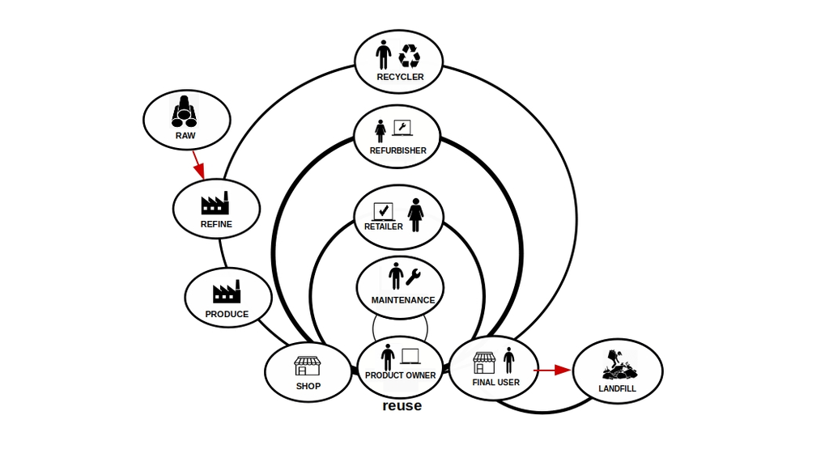

To make and scale a circular economy, businesses, governments, and society must work together. But today it is uncertain if reused digital devices may end up being exported illegally and potentially polluting the environment. Such risk and slippage is the main drawback in the promotion and the practice of reuse in public and private organisations.

The circular economy is a new paradigm to change the current consumption model based on buy, use and throw away. Circular economy in electronics is, first, to preserve in use the products and components that have been already manufactured, and second, to recover raw materials when devices are no longer repairable and functional.

Circularity means making self-sufficient system that does not require inputs of raw materials and does not have losses. losses are waste that ends up in landfills where materials cannot be recovered.

In circular economy, products and materials are seen as assets, businesses are seen as its users, that should repair, upgrade and reuse their devices and materials to maintain them in use as much as possible.

We define the Circular Economy of electronics reuse as the result of performing all viable reuse processes until the use value of devices does not allow further reuse, and that at the end of any reused device is recycled.

Therefore, there are three principles that are key to achieving Circular Economy of electronics: Reduce, Reuse and Recycling. we should ensure at the time of recycling devices have low use value, so there is no premature recycling.

## Increase disposal and demand for reuse

The ultimatelly aim is to achieve a cultural change towards a culture of reuse and recycling. On the one hand it is necessary to **stimulate disposal for reuse** in a way that Product Owners (Business and Public Administrations) willing to dispose reusable devices choose a refurbisher / reuse centre rather than a final recycler and this goes thought generate the enough confidence that product owners’ devices are treated in accordance with circular economy principles.

### Stimulate disposal for reuse

> **How can the Product Owner identify which refurbishers have internalized properly these principles?**

The following figure @ref(fig:figreuseimpact) shows a typical case of disposal for reuse.

Discarded devices by Product Owners (public or private administrations) are collected, refurbished, reused and recycled after few years or directly recycled if it has been detected that there is no demand. The intention of the Product Owner is that these devices are reused as long as possible for a specific segment (e.g. schools) and then non-premature recycled at an authorized recycling point.

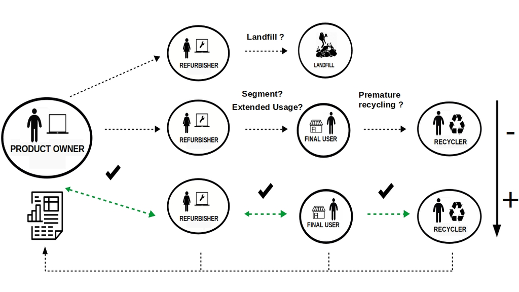

Impact accounting without affecting business privacy

The challenge at therefore is Product Owners to choose businesses with the highest reuse performance (thus avoiding premature recycling) and to take custody of the reused assets to be recycled at the end of their life.

> **Which refurbisher should the Product Owner choose in order to increase the overall circular economy?**

As we will see in the latter there is a need for Product Owners to identify refurbishers with accountable reuse and recycling impact.

### Stimulate demand for reuse

That problem is called “The Market for Lemons: Quality Uncertainty and the Market Mechanism” (AKERLOF 1978) and it refers to issues that arise regarding the value of an investment or product due to asymmetric information possessed by the buyer and the seller. In our use case first the Product Owner has a product for which it wants to be able to transparently demonstrate the quality to the Refurbisher, and second the Refubrisher wants to demonstrate to the consumer. In order to minimise the problem the actions to be taken include trying to reduce information asymmetries and be able to stimulate demand and this involves generating sufficient confidence about the potential for reuse and quality of the devices before refurbishment (Product owner to refurbisher) and after (refurbisher to final user).

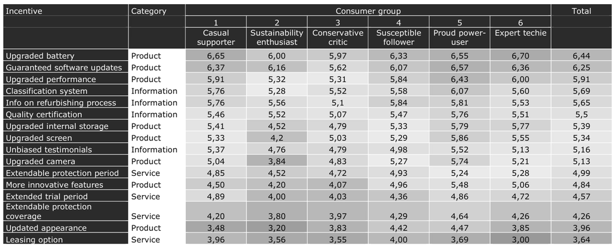

Circular Economy Challenge

Mugge, Jockin, and Bocken (2017) investigated the potential of selling refurbished smartphones through a quantitative study. It conducted an online survey questioning 250 respondents to study the impact generated from various incentives that reuse centres can undertake to improve the purchase intention of refurbished phones. Or to put it another way: the question is: how can the reuse market be stimulated? The results are given for 6 different user groups in Figure @ref(fig:figmugge). We see that in addition to the product itself, it is key to provide information that allows the product to be classified, to inform about the refurbishment process and quality certification.

# Ecosystem

## Overview

This section describes the professional roles of the core actors and the relationships between them in an ecosystem.

**Supplier**

A role an entity might perform by disposing digital devices. Suppliers have out-of-use devices that may or may not have the potential to be reused. They are usually companies and public administrations that want their devices to be reused and therefore contact refurbishers to do this work. The dispose operation represents a change of ownership from supplier to refurbisher. In cases where the supplier declares the devices as waste then they are considered a waste producer and must provide their producer code and environmental identification number (in Spain this is the NIMA code).

**Refurbisher**

A role an entity might perform by collecting, refurbishing and reselling/donating digital devices considered as waste or products. Their main activity is to collect out-of-use devices from suppliers, refurbish or prepare for reuse (if it is e-waste), and redistribute digital devices to Final Users. Refurbishers are mainly classified into two types, those that can deal with devices that are considered as waste and those that can only deal with devices that are considered as products, in the figure @ref(fig:ereuseloops) the professional loop represents the first classification and the citizen loop represents the second classification. Refurbishers classified as waste managers must have a credential that represents them as an authorised waste manager for doing preparation for reuse treatment, in addition to having an environmental identification number (in Spain this is the NIMA code).

**Recycler**

A role an entity might perform by recycling digital devices. Like refurbishers, they collect digital devices but unlike refurbishers they do not take actions to promote reuse (repair, upgrade) but only take actions to preserving raw materials such as dismantling and shredding. The recyclers must have a credential that defines the authorisation to do the raw material recovery treatment, as well as the environmental identification number.

**Managers**

A role an entity might perform by managing digital devices. They are the entities that formalize the agreements with the public administrations and act as umbrellas between all the refurbishers of a territory. The managing entities in no case refurbish or resell devices, they only receive the inventories of the suppliers to share them following criteria with the refurbish entities. Managers can or can not receive ownership of the devices and can either transfer ownership to the refurbishers and these to Final Users or keep ownership on comodatum throughout their life cycle.

**Retailer**

A role an entity might perform by reselling digital devices to Final Users. In cases where the refurbisher does not have or does not want to have contact with the Final Users they collaborate with the retailers. Retailers can be web platforms or B2B/B2C companies or p. These are entities participate in several ways: i) finding demand and / or ii) with various services, such as hardware and software maintenance, iii) with end-user training services, 4) with various services and collaborations.

**Final User**

A role and entity or individual might perform by using digital devices. Life extension time should only counted when the device is being used by a Final User.

(ref:ereuseecosystem) eReuse Ecosystem overview.

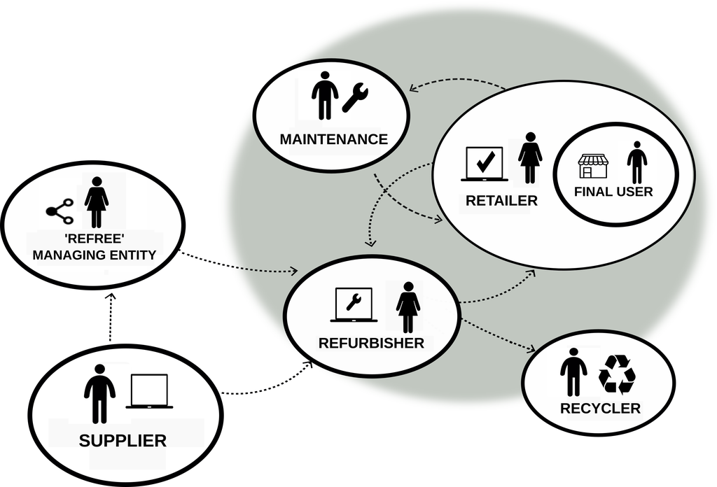

## Impact and Outcomes

Impact and outcomes are terms used to describe change at different levels. Outcomes – the short- to medium-term effects of an intervention – and eventually impacts.

> Positive and negative, primary and secondary long-term effects produced by a development intervention, directly or indirectly, intended or unintended.

The intended impact is to extend device lifetime and ensure final recycling. The principle of circular economy is to try extend devices lifetime as long as possible avoiding the premature recycling.Recycling should only take place at the end of their useful life and at that point try to recover as much as possible of the raw materials they contain.

The intended impact understood as long-term effects produced by our intervention tecnological roadmap and others activities

1. Increase devices lifetime through increasing durability, reparability, reusability and upgradeability.
2. Increase proper recycling.

The expected outcomes understood as achieved short-term and medium-term effects of an intervention’s outputs:

Expected outcomes by groups

| Id | Outcome | A | B | C | D | E | F |
| --- | --- | --- | --- | --- | --- | --- | --- |
| o1 | Devices are in use rather that stored | X |  |  |  |  |  |
| o2 | Allocation criteria of devices according its service | X |  |  |  |  |  |
| o3 | Increase procurement of second-hand devices and product-as-service | X | X |  |  |  |  |
| o4 | Criteria for buying devices is more focused on durability and reparability | X | X |  |  |  |  |
| o5 | Share data on devices circularity | X | X | X | X | X | X |
| o6 | Only dispose for external reuse those devices that are not reusable internally |  |  | X |  |  |  |
| o7 | Consumers dispose with impact accountable ITADs/refurbishers |  |  | X |  |  |  |
| o8 | Prioritize disposal for reuse rather that disposal for recycling |  |  | X |  |  |  |
| o9 | Circular economy accountable |  |  | X | X |  | X |
| o10 | Trace refurbished devices until recycling |  |  | X | X |  |  |
| o11 | Financially compensated for collecting low reuse potential devices |  |  | X |  |  |  |
| o12 | Reduce exporting of non-durable and non-repairable devices |  |  |  | X |  |  |
| o13 | Devices easily openable and no software locks | X | X | X | X | X | X |
| o14 | Batteries that are easily removable and replaceable without special tools | X | X | X | X | X | X |
| o15 | Continued operating system support | X | X | X | X | X | X |
| o16 | Spare parts and repair information that are accessible to everyone |  |  |  |  |  |  |
| o17 | Repairs affordable and accessible (cost of spare parts) |  |  |  |  |  |  |
| o18 | Compare reparability information of devices |  |  |  |  |  |  |
| o19 | Devices can be fully disassembled with an standard tool |  |  |  |  |  | X |
| o20 | Receive only devices without reuse potential |  |  |  |  |  | X |
| o21 | Report final recycling of devices |  |  |  |  |  | X |
| o22 | Reduce costs of dissasembly |  |  |  |  |  | X |

Note:  
Here is a general comments of the table.  
<sup>1</sup> A: Final Users of type business;  
<sup>2</sup> B: Final Users of type Individuals;  
<sup>3</sup> C: Suppliers disposing for reuse;  
<sup>4</sup> D: Refurbishers/ITADs;  
<sup>5</sup> E: Repairers;  
<sup>6</sup> F: Recylers;

# User Stories and Use Cases

## Introduction

### What is a User Story and a Use Case

Is a User Story the same thing as a Use Case? Although there are some similarities between User Stories and Use Cases, User Stories and Use Cases are not interchangeable; both User Stories and Use Cases identify users and they both describe goal, but they serve different purposes.

A **user story** is an informal, natural language description of features of a software system. They are written from the perspective of an end user or user of a system. A User Story is a note that captures what a user does or needs to do as part of her work. Each User Story consists of a short description written from user’s point of view, with natural language. Unlike the traditional requirement capturing, User Story focuses on what the user needs instead of what the system should deliver. This leaves room for further discussion of solutions and the result of a system that can really fit into the customers’ business workflow, solving their operational problems and most importantly adding value to the organization.

A **Use case** is used to capture user (actor) point of view while describing functional requirements of the system. They describe the step by step process a user goes through to complete that goal using a software system. A Use Case is a description of all the ways an end-user wants to “use” a system. Use Cases capture all the possible ways the user and system can interact that result in the user achieving the goal. They also capture all the things that can go wrong along the way that prevent the user from achieving the goal.

### Similarity between User Stories vs Use Cases

If we consider the key component in both approaches:

- User Stories contain, with user role, goal and acceptance criteria.
- Use Cases contain equivalent elements: an actor, flow of events and post conditions respectively

### Diferences between User Stories vs Use Cases

User Stories are centered on the result and the benefit of the thing you’re describing, whereas Use Cases can be more granular, and describe how your system will act. The details of a User Story may not be documented to the same extreme as a Use Case.

- User Stories deliberately leave out a lot of important details. User Stories are meant to elicit conversations by asking questions during scrum meetings.
- Small increments for getting feedback more frequently, rather than having more detailed up-front requirement specification as in Use Cases.

> User stories don’t provide the details the development team needs to do their work.

## Use cases

> User Stories contain, with user role, goal and acceptance criteria.

> User Story focuses on what the user needs instead of what the system should deliver

### Use Case: Producer responsibility organization - reporting of e-waste

user roles: supplier, producer responsibility organizations, refurbishers, recycler, Final User, collection point and auditors. goals: reporting preparation for reuse and e-waste management, devices are considered ewaste in the supplier

Un **supplier** (Productor de residuos de (ej: Movistar)) contrata a un **producer responsibility organizations** (PRO, ej: Ecoasimelec) para la gestión de los dispositivos usados que tiene en propiedad o de sus clientes. Estos dispositivos estan en contenedores ubicados en sus tiendas. El PRO contrata a **refurbishers** [de tipo gestores de preparación para la reutilización] autorizadas por las comunidades autónomas. Las **refurbishers** (ej: Andròmines) recojen los contenedores de las tiendas y hacen un proceso de selección. Los dispositivos reutilizables se reparan/mejoran y venden de segunda mano a **final users** y los no reutilizables se depositan en contenedores para transferirse a **recyclers** de tratamiento (ej: electrorecycling), y estos los mandan a las refinerias que recuperan las materias primeras. A los dispositivos de segunda mano se crea un Digital Product Passport con la descripción del producto, los componentes y las pruebas de funcionamiento realizadas. Los **Final users** (consumidores de segunda mano) deben poder acceder de manera online a este documento generado por las reacondicionadoras y poder verificar que se ha generado con software acreditado. Los dispositivos en reutilización cuando llegan al final de su vida deben terminar en un **collection point** (punto limpio/verde/deixallería) por lo que los Final Users deben poder transferirlos a una de estas instalaciones. La información del impacto generado en economía circular, la cadena de custodia y las credenciales de sus participantes debe poder verificarse por parte del los participantes y **auditors** preservando la privacidad.

### Use Case: Refurbisher - impact accounting and reporting

user roles: refurbishers, suppliers (of unused devices), recycler, Final User. goals: report lifetime extension and final recycling, devices are considered products by the supplier and the refurbisher.

Refurbishers are business collecting used devices, repairing and reselling them.

El **refurbisher** Andròmines recibe dispositivos usados de un **supplier** de dispositivos usados (i.e: Ayuntamiento de Barcelona) que quiere que sus dispositivos se reutilizen y reciclen de manera adecuada. El refurbisher recoje y hace un inventario de los dispositivos y los filtra según potencial de reutilización. Los que tienen un potencial de reutilización bajo los mandará a un **reciclador** que los desmantela y manda a una fundición, los que son reutilizables los venderá/donará a **Final users** para que sean reutilizados. El objetivo del refurbisher es poder reportar a su supplier el impacto generado en economía circular (ver annexos - Report on IT deed of assignment - reuse and recycling progress) que principalmente es el tiempo de extensión de vida del dispositivo y su reciclaje final por parte de un reciclador autorizado. En cuanto a contabilizar el impacto la dificultades para el refurbisher son: 1) poder saber si los Final Users después de su reutilización han llevado a un punto autorizado de reciclaje el dispositivo, 2) saber si los recicladores a los que manda lo que no es potencialmente reutilizable estan autorizados por las autoridades competentes y saber si se han reciclado 3) saber durante cuantas horas y años se han reutilizado los dispositivos. Esta información debería ser verificable y auditable por parte del refurbisher, suppliers y auditores a los que el refurbisher se lo permita. Entendemos por verificable la posibilidad de tener la certeza que en una transferencia de dispositivos las dos partes han participado (confirmando) y que se han transferido unos dispositivos con una identidad única.

Testimonials:

> As a (user) ___ I Can (action) ____ So that (value for the user) ____

As a refurbisher I can :

1. Puedo saber las horas de extensión de tiempo de vida de los dispositivos que di a un reseller o a un Final user
2. Puedo saber si los Final Users han reciclado los dispositivos al final de su tiempo de vida útil
3. Puedo generar un informe de cadena de custódia que … y cada transferencia es verificable
4. Puedo generar un informe de impacto agregado y el impacto de cada device puede ser conocido

Ejemplo: De los 100 dispositivos que el donante me dió puedo saber: - 70 se han reutilizado por parte de usuarios finales que han extendido el tiempo de vida en X horas y 30 se han reciclado sin reutilización por tal usuario - de 70 reutilizados se tenemos conformidad del reciclaje de 30 de ellos y se han reciclado por estos usuarios (no hace falta que sea anónimo)

### Use Case : Refurbisher - seller of second-hand devices

user roles: refurbishers, resellers and Final User. goals: report the refurbishment process and quality of second hand devices refurbished

El **refurbisher** Solidança ha reacondicionado (reparación / upgrade / install SO) un conjunto de dispositivos. Quiere poder informar a sus potenciales compradores que son **resellers** (B2B) o **Final Users** (B2C) de: 1) la identidad del dispositivo y una descripción de los componentes que incluye, 2) el proceso de reacondicionado (borrado de datos, tests,…..). El refurbisher debe poder mandar esta información a sus potenciales compradores mediante web o documentos y estos poder verificar que esta información es creible, entendido como: 1) se ha generado mediante herramientas software sin manipulación, 2) se generó en una fecha determinada. Además, el comprador al recibir el dispositivo debe poder usar unas tools software que le aseguren que es la misma identidad y descripción.

Testimonials:

> As a (user) ___ I Can (action) ____ So that (value for the user) ____

As a refurbisher with role (seller) of refurbished devices I can :

1. Puedo generar un documento (pdf, url) con la identidad del dispositivo y los componentes que incluye
2. Puedo generar un documento (pdf, url) con el proceso de reacondicionado y las pruebas realizadas, especialmente el borrado de datos y el test de disco y de stress.

As a Final User with role (buyer) I can:

1. Verificar que el dispositivo que tengo físicamente es un dispositivo virtual
2. Tener la garantía que la información se ha generado con un software y que no ha sido modificada de manera manual.

### Use Case: Supplier - Refurbishers credentials/reputation

User roles: Supplier and refurbisher.

Un **supplier** es una empresa o una administración pública que tiene dispositivos usados que quiere que se destinen a la reutilización. Para ellos es difícil identificar que refurbishers tienen la capacidad de poder reportar de manera fiable el impacto creado en economía circular. Quieren poder identificar quales tienen esta habilidad por lo que algun sistema de credenciales/reputación les facilitaría esta búsqueda. Otras preguntas.

What questions should we be able to answer?

- Which refurbisher/ITAD should the Product Owner choose in order to increase the reuse and the final recycling? Are there any metrics or standarized definitions for measuring impact and comparing? see figure @ref(fig:figreuseimpact)
- How they can encourage refurbishers/ITADs to account the impact of reuse and report the final recycling? Is there guidelines that provide a common basis for collecting this data? are there any standarized certification, third-party analyses for concisely communicating social and/or environmental performance? Are there any instruments for facilitating the diligence, assessment, monitoring and reporting of impact?
- How can they or third parties know with certainty that a device has been reused and recycled without requiring the actors having to disclose business information or that may penalise them negatively? so how they can verify reuse and finaly recycling.

### Resum of User needs

Resumen de las necesidades expresadas en las user stories

Se incluyen las credenciales detectadas: https://www.w3.org/TR/vc-use-cases/#user-needs

**UN.1 Suppliers and refurbishers as waste producers**

Un supplier del tipo Productor de Residuos quiere transferir un contenedor de dispositivos a una reacondicionadora de PxR. Antes de la transferencia el Productor debe de informar al gestor sus credenciales el código NIMA (ej: 0100604396) y el gestor debe informar al Productor de su código NIMA y código de gestor (ej E-1503.15). La trazabilidad de dicha transferencia se debe consultable/verificable en la blockchain pero sin revelar los participantes ni sus códigos pero asegurando que ambos tienen las credenciales en vigor y en el caso de gestor que su código lo habilite para ser preparador para la reutilización. La blockchain debe registrar el trade de ambas partes.

**UN.2 Refurbishers creating creating Digital Products passports of Prepared for Reuse devices**

El refurbisher (ej: Andròmines) recoje un contenedor de dispositivos del Productor de Residuos. Hace el proceso de preparación para la reutilización (era residuo), crea un Digital Product Passport y revende/dona los dispositivos. El DPP contiene la descripción del producto, los componentes y las pruebas de funcionamiento realizadas. Los consumidores de segunda mano deben poder acceder de manera online a este documento generado por las reacondicionadoras y poder verificar que se ha generado las credenciales de un software eReuse y con las credenciales de componentes y de funcionamiento adecuado. Los consumidores tambien deben poder regenerar el DPP en caso de que se pierda la etiqueta o quieran validar que el producto que compraron es el que recibieron.

**UN.3 Refurbishers transfering ewaste to Recyclers**

La reacondicionadora quiere transferir un contenedor de dispositivos a una recicladora de tratamiento. El contenedor puede tener los dispositivos desmantelados o no y debe de tener un peso. El contenedor tiene tanto dispositivos con DPP como dispositivos sin. Antes de la transferencia ambas partes deben poder acreditar a la otra de sus códigos NIMA (ej: 0100604396) y de gestor (ej E-1503.15). La trazabilidad de dicha transferencia se debe consultable/verificable en la blockchain pero sin revelar los participantes ni sus códigos pero asegurando que ambos tienen las credenciales en vigor y que los códigos de gestores permiten la gestión de este tipo de residuos. La blockchain debe registrar el trade de ambas partes.

**UN.4. Final users disposing in collection points**

El consumidor final quiere llevar sus dispositivos no reutilizables a una instalaEsticción de recogida de residuos municipal (punto limpio/verde/deixallería). El consumidor debe de poder validar de si la instalación tiene una credencial de recogida de residuos municipales. La instalación debe de poder regenerar el DPP para informar que ha recogido el DPP para así confirmar que el producto dispositivo es en realidad el DPP. La trazabilidad de dicha transferencia del consumidor a la instalación de recogida debe de ser consultable/verificable en la blockchain pero sin revelar la identidad de los participantes.

## User Stories

# Roadmap: building blocks, conditions or capabilities

All actions will be described in detail in the following sections of this chapter. We divide the actions into two types, transversal and vertical actions. The transversal actions, which we also call building blocks, are a basic unit or component from which vertical actions are built up. Vertical actions or requirements are what we want the participants of the ecosystem to be able to do.

Actions/Outputs are the products, goods and/or services which result from a development intervention. These are designed to produce the outcomes explained in previous section. – the short- to medium-term effects of an intervention – and eventually impacts. Whilst the terms are in common use, there is great inconsistency in how they are interpreted.

> interventions required for to implement the above outcomes
1. Information systems and tools
   1. Digital inventory for full-lifecycle traceability with digital twins instances and product passport
   2. A verifiable, private and decentralized data registry for devices, documents and organizations
   3. Tools for auditing compliance, quality of devices and impact of organizations and products
   4. Tools and sensors to update digital twins instances
   5. Data compliance for devices data erasure
2. Circular economy accountability
   1. Impact measurement framework
   2. Consumption accountability on lifetime extension and recycling
   3. Reuse and recycling accountability
   4. Product accountability on quality, durability and reuse potential
3. Incentives for circularity
   1. Update digital twins inventory
   2. Share devices lifecycle and durability data
   3. Prioritize reuse rather than recycling
   4. Ensure final recycling in certified recycling facilities

## Information systems and tools

### Asset tracking for full-lifecycle traceability

Asset tracking refers to the method of tracking physical assets (https://en.wikipedia.org/wiki/Asset_tracking). Along its lifetime from assembly to recycling, a device may need to move to different operating states, locations and its ownership change. This pose the need to have an up-to-date inventory of devices and to be able to transfer information between owners, from the initial manufacturer to the final recycler.

Types of asset tracking:

1. Units and weights.
2. Synthetic identifiers: Basic (Bar code / QR), smart (RFID, Lora,…)
3. Hardware Fingerprints:
4. Waste fractions

#### Units and weights.

Are the simpliest traceability.

#### Synthetic identifiers,

like internal database identifiers (Waltermire, Wunder, and Halbardier 2011), cannot be used outside an organisation as they cannot be regenerated if lost, and serial numbers are not always unique [ereuse2015]. They are used to report to suppliers or manage traceabilit at internal level.

#### Fingerprints

The hardware fingerprint is information collected about the hardware of a remote computing device for the purpose of identification. For example Microsoft uses to link software licenses to specific hardware. One use case of eReusea is that a Refurbisher can certify a device has been transferred to a recycler. To cope with that, the Refurisher should ask to a recycler to run software to confirm that a device is in recycler’s possesion. This property is not given in the case of conventional bar codes tags or wireless tags, because you only can proof you have got the tag, not the device that was attached to it.

In the same way that Microsoft knows that a license is in use by a device or google knows which devices a user is using, eReuse is able to know with certainty:

1. Possession. a devices is in the possession of a user.
2. Operating status. A devices has surpassed quality and benchmark tests
3. Devices specs and components. A devices has specific specs and components.
4. Data wipe. The hard drives has been data wiped.

eReuse.org proposes a HID to track devices or components. It results from the concatenation of the manufacturer name, the model and serial number of a device, for example acer-aod270-lusga_0d0242201212c7614. These HIDs are typically attached in stickers or printed on the devices.

### Hardware Fingerprint Unique Hardware Identifier

eReuse consider that a Hardware Fingerprint is candidate for a Digital Product Passport if: 1. standard and globally unique: the ID must be unique and able to interface with systems around the world 2. self-generated on a internal and unmutable device information: it must be able to be generated from internal components with low frequency of replacement and that the concatenation results in a potentially unique identifier 3. is an anonymous id: if you have the device physically and permissions you can generate the id

eReuse consider a valid process of creating the passport if we can ensure the veracity of the information, that means: 1. the collection of the hardware information has been performed with open software tools 2. the executed software has not been modified

By collecting this information using software tools that can read it, we can ensure the veracity of the information. that a device will always have a unique machine identifier.

Point 2 (serial components) and point 3 (anonymisation) require us to create two identifiers. A first identifier that we call Unique Hardware Identifier (UHI) that will be known by the users that interact with the device (who physically have it) and a Digital Product Passport that will be an anonymisation of the UHI.

The values needed to create a unique machine identifier are: i) the brand, ii) the model, iii) the serial number and iv) the network card identifier of the device or the motherboard id. With these four identifiers we can ensure that the identifier is globally unique. For example the following identifier

desktop-hewlett-packard-hp_compaq_8000_elite_sff-czc038bqt9-00:23:24:13:a5:37 Figura 15: Unique Hardware Identifier (UHI)

#### Anonimized Unique Hardware Identifier

Before sending the UHI to a partner it should be anonimized. The anonymisation process is carried out by a hash function. As a result of applying the hash function (in this case SHA-256), the resulting unique and anonymised hardware identifier has been:

e71f2e95da5455b4d8d27077b7b9e1919df918d11e7b69a2905f7da14cd35359

Figura 16: Anonimized Unique Hardware Identifier (AUHI)

hash function: És un algorisme o funció per sumaritzar https://ca.wikipedia.org/wiki/Funció_hash per detalls).

#### Creating the Digital Product Passport

Una vez se tiene el AUHI ya es posible crear un DPP. Debe mandarse el AUHI a un servidor de DPPs que te devolverá un código único. Este servidor anotará quien es el holder, issuer y el verificados.

Holder: Holders are the owners of digital identities. They have ultimate control over their data and choose how much and with whom they share their data with.

Issuers: Issuers are trusted third parties or authorities that generate and issue credentials to holders, such as health records or identity documents.

Verifiers: Verifiers

Verifiers are any third parties that need to verify the authenticity of a holder’s data. A verifier might, for example, need to validate that the holder is who they say they are

From the machine identifier with the hash function applied (figure 16) from the previous step we will do a whole series of steps to create a passport number.

1. Registre al sistema d’inventaris. El centre de reutilització ha de registrar el dispositiu amb unes eines que recullen informació invariable del maquinari i aplicar una funció establerta de hash. eReuse posa a disposició tant les eines per recollir la informació com el sistema de traçabilitat d’inventaris.
2. Creació d’un número de passaport no vinculat. El centre de reutilització crearà al seu sistema d’inventaris una etiqueta de tipus passaport de producte. Ha d’anar a l’opció “tags” de tipus “unnamed tags” (veure següent figura). En aquest moment es fa una petició al sistema de passaports d’eReuse i aquest li retorna un número de passaport únic (per exemple: DFR53). Aquest número encara no té cap dispositiu assignat.
3. Vinculació d’un passport a un dispositiu. Al seu sistema d’inventaris, el centre selecciona el dispositiu i el número de passaport que li vol assignar. I envia aquesta informació (identificador de maquinari anonimitzat amb la funció de hash i el número de passport). El sistema de passports d’eReuse fa aquest vincle. És clau que la informació quedi anonimitzada per tal que eReuse no pugui saber de quin dispositiu en realitat es tracta.
4. Regeneració del número de passaport. si les consumidores finals o nous centres de reutilització / reciclatge extreuen l’etiqueta amb el número de passaport, ha de ser posible autogenerar el número inicial. El procés de regeneració és similar a l’anterior, però en aquest cas, quan el nou usuari vulgui associar el dispositiu amb el número de passaport, el sistema de passaports d’eReuse li farà saber que ja existeix 11 un número de passaport per aquell dispositiu i li retornarà.

### Auditing compliance

quality of devices and impact of organizations and products

An audit aims to establish whether information systems are maintaining the integrity of stored and communicated data. There are certain requirements that the refurbishers’ system must have in order to allow for this being audited in impact. The requirements are inmutability, verificability and privacy of the data. This is where Distributed Ledger Technology comes into play. In this section we will look at the properties that these technologies provide to justify their use.

Required features for data:

> Inmutability, verificability and privacy of the data

A verifiable, private and decentralized data registry for devices, documents and organizations

#### Inmutability

Immutability means unchangeability. Immutable data is a piece of information in a database that cannot be (or shouldn’t be) deleted or modified after it’s creation. Most traditional databases store data in a mutable format, meaning the database overwrites the older data when new data is available. This is where Distributed Ledger Technologies (DLTs) or blockchains come into play. Immutability is one of the key features of DLTs. It is a replicated and synchronised digital registry, where it is written by consensus of the participants, distributed to different locations and organisations, without a central administrator, which structures the data and operations in such a way that only data can be added but it is not possible to modify those already accepted. It is impossible for any entity (for example, a government or corporation) to manipulate,replace, or falsify data stored on a DLT.

#### Verifiability

Verifiability is an action to be able to confirm that a fact/data is supported by an attestation at a certain moment. As will be explained in the chapter on technology for ensuring the verifiability we use a block explorer of the DLT where it is possible to search the entries of the registry that correspond to a determined event or device, to provide a set of registered attestations that allow to confirm some facts that appear in a document, as for example a certificate of an action or set of actions during the life or multiple lives of a device.

#### Privacy of personal and business data

When Product Owners (companies, governments or individuals) need to get rid of their digital devices to have a new life (reuse), they transfer it to ITADs/Refurbishers and Recyclers. If the device is reused then the circularity of the product owner increases, if it is recycled prematurely then it drops. In the process of data collection for impact accounting, the refurbisher must request data from his customers and suppliers, and in turn, to them request to the following actors of the reverse supply chain until the final recycler.

The problem we have is how reconciling business privacy with being able to measure social and environmental impact. The Refurbishers / Retailers / ITADs / Recyclers / Trade-in actors of the reverse-supply chain are in competition to reach Product Owners, Final Users, and commodity refiners so they do not feel comfortable in openly sharing this data.

Hechos a demostrar sin tener que revelar la información de negocioes y Final users:

Como el refurbisher puede saber si un dispositivo se ha reciclado finalmente? La verdad es que * El reciclador va a querer comunicar al refurbisher en que refineria ha reciclado el dispositivo?

Como puede el reciclador demostrar que se ha reciclado sin tener que revelar quien lo ha hecho?

he know your customer or know your client guidelines in financial services require that professionals make an effort to verify the identity, suitability, and risks involved with maintaining a business relationship. The procedures fit within the broader scope of a bank’s anti-money laundering policy.

On the one hand, the devices, actors and end-users must be completely anonymous and, on the other hand, impact accounting must provide guarantees of trust, verifiability, irreversibility and tamper proof to ensure sellers/donors that positive impact is generated if they divert their devices to reuse streams.

Our last requirement is ensure the privacy of data. This is where privacy must be reconciled with the ability to account for impact. Data if its not protected could disclose the actors business privacy or personal information, but if its not accountable that do no allow to account the circular impact generated such as extended life time and final recycling.

Tal com veurem al capítol de tecnologia, Per la immutabilitat fem servir el que en anglès s’anomena “distributed ledger technology” (DLT) o “blockchain”,

The data of the traceability systems of the entities federated in eReuse are in decentralised systems that should preserve business privacy.

un dels requeriments que tenim es fer ús de d’un llibre de registre digital fent servir tecnología blockchain per tal d’assegurar la seva immutabilitat (no poder canviar el passat). i verificabilitat (poder confirmar que un fet està suportat per un atestat en un cert moment que només és possible amb certes dades, però sense les dades, només amb un resum/signatura). En resum, la funció que fa un notari o fedatari.

Per la verificabilitat fem servir un explorador de blocs de la DLT on es poden cercar les entrades del registre que corresponen a un esdeveniment o dispositiu determinat, per aportar un conjunt d’atestats registrats que permeten confirmar uns fets que consten a un document, com per exemple un certificat d’una acció o conjunt d’accions durant la vida o múltiples vides d’un dispositius is the blockchain.

In this action we justify the need to implement a blockchain and explain the one that has been developed in the framework of the project, as well as the mechanisms followed by reuse centres to self-certify and those undertaken by third parties to carry out auditing processes.

## Circular economy accountability

Measuring circularity indicators pro- motes a transition towards a circular economy, as it builds the knowledge base for environmental action and sustainability; it helps achieving requirement R2 (Utility maximisation) through data analysis and reporting. Open data allows any internal or external participant to assess different indicators about digital devices, such as statistics about different cycles, and durability of different groups of devices. This requires collecting a specific set of required data and providing mechanisms for data extraction (for transparency) and data aggregation functions (to preserve privacy) when dealing with more private data. These requirements are in line with the recent European action plan for the circular economy, but also relevant to bootstrap an inclusive economy in developed and developing countries which keeps devices longer at higher values creating both socio-economic development and lower environmental impact.

### Impact measurement framework

There are two main challenges to fostering the circular economy of digital devices: on the one hand, when owners want to dispose of their device they should opt for dispose for reuse instead of dispose for recycling; but who do you turn to for guarantees of reuse? on the other hand, when consumers requiere a device they should opt for second-hand devices regardless of their economic situation. The latter will be possible if second-hand devices have a proven quality and a long durability that could make consumers do not resent them, so it should be as repairable (replacement of worn components), upgradeable (adding new components) and upgradable (they can work with current operating systems and applications) as possible.

Product Owners and Refurbishers can play a central role in stimulating disposal and demand for reuse. In an analogy to impact investment, Product Owners invest with their disposed assets in those refurbishers that will provide the greatest guarantee of impact, or at least are accountable. Refurbishers will have to account for the impact they generate, so it is essential for them to use a common framework for impact measurement methodology that can be verified by Product Owners and other parties. In addition to being able to measure the impact generated by organisations, it is necessary to have information on how reusable the devices are, this information is useful for refurbishers and for consumers who choose to consume second-hand.

#### Standards, certifications, methodologies and metrics

The numerous interpretations of circular economy and impact objectives have posed a challenge to Product Owners and refurbishers seeking to align around a shared set of goals. Because there are no clear specific objectives yet we suggest trying to answer the day-to-day questions for which foresee an impact on circularity principles and to the UN Sustainable Development Goals. In addition to the objectives, our framework should provide content in the following categories: standards, certifications, methodologies and metrics. These building blocks come into play at different stages of the impact management process.

#### How do we measure performance: metrics and indicators

Discarded devices by public or private administrations (Product Owners) are collected and refurbished or recycled if it has been detected that there is no demand. When the Product Owner requires impact data such as lifetime extension they request a report from the refurbisher. This impact data in turn feeds into the product owner metrics to calculate their circularity performance.

We need to know what works, what doesn’t and why and that means turning to metrics. The field of metrics can be difficult to navigate due to the variety of terms and definitions used. What is the difference between a metric and an indicator (Verstraeten-Jochemsen, Baars, and Daniels 2020)

- **Metric** are standarized definitions for measuring and comparing impact. Is a method we employ to understand change over time across a number of dimensions. We use it as a catch-all term to describe the method used to measure something, the resulting values, as well as a calculated or combined set of indicators.
- **Indicator** is a crucial element of a metric, referring to a single value and its unit, and used to indicate (hence the name) a specific trend or performance.

#### Are there specific methodologies and tools for measuring

Methodologies and tools are instruments for facilitating the diligence, assessment, monitoring and reporting of impact. Many of the metrics considered are partly or fully automated using the eReuse software that enable easy application and reduce the risk of errors.

#### Are there an standarized way of measuring reuse and recycling performance

Standards are metrics that have gone a certain degree of scrutiny and testing, and are commonly accepted as a standardised way of measuring. Technically, one can consider both ‘informal’ standards and standards that have officially been documented and published by standardisation organizations. Today there is no standard method to measure reuse and recycling so we can consider the eReuse standard as informal in the absence of adaptation to future standards as they emerge.

#### How federated members can be assessed in reuse and recycling

A certificate is a specific type of standard that can not be applied by the organisation itself but requires a third party to assess whether the company’s performance has been according to a certain standard. They usually result in a product label being issued by the third party.

### Consumption accountability on lifetime extension and recycling

### Reuse and recycling accountability

### Product accountability on quality, durability and reuse potential

### Incentives for circularity

# Technology

Ereuse has developed software, protocol and data commons for local refurbishment ecosystems with traceability and impact accounting. Ereuse is a B2B, open-source system ready to be used and extended. The role of eReuse is to coordinate a roadmap and ensure the code is freely available to the federation of refurbishers. The software development is supported by contributions from research centres, companies and the community.

eReuse offers a set of tools that automate the process of secure collection and traceability monitoring in the management of electronics (Workbench and Devicehub). eReuse has developed a Distributed Ledger Technology (DLT) with a block explorer in order to ensure: immutability (not being able to change the past), verifiability (being able to confirm that a fact is supported) and privacy (not showing identifiers of devices, businesses or people).

In the eReuse software every single piece of an old laptop or desktop collected from a company or a government by the refurbisher is broken down into individual pieces, recorded and indexed in a transparent and privacy-preserving database. The refurbisher repairs and rebuilds the machines, and their value and quality are reported in the system and potential customers. Refurbishers then loan the repaired machine in a second-hand market and monitor the process till every single item is correctly reused and finally recycled. As a result, eReuse systems prevent much more waste from going to landfill, extend the lifetime of digital devices and make obsolescence visible (real durability of devices in hours and reparability). This contributes to changing consumer habits and ultimately manufacturers’ policies by empowering governments, refurbishers and citizens with new DLT-based technology that provides for device traceability and impact accounting.

Until now, there has been no standard traceability protocol to assess impacts and bring transparency to the refurbishment and reuse sector of electronic devices. In the business as usual refurbishers providers have non-transparent redistribution channels based on undisclosed business relationships. This prevents impact accounting. eReuse enhances trust while conciliating business privacy. eReuse has developed a disruptive traceability & impacting accounting as a stand-alone service that can be used by existing refurbishers. eReuse enable an infraestructure to trace the reverse-chain of ownership custody, and reports data to assess social and environmental impact.

eReuse systems are managed and governed locally by governments and business (Product Owners) and social enterprises (Refurbishers). , and refurbishers collect, refurbish and deliver to business and citizens (Final Users) willing to reuse a second-hand device.

## Open data

A public dataset (1) about reuse of computing devices in eReuse under CCBY4.0 license: The original dataset has been anonymized and exported from the refurbishers’ Devicehub.

1. Data set July 2020. We have limited the study to only refurbishers with operations in Spain that has accepted the data commons license. Data collected between 2013-10-08 and 2019-06-03. https://dsg.ac.upc.edu/sites/default/files/dsg/eReuseDataJun2019_0.html

## Open Code

The following paragraphs describe from a more technical point of view the respective components that are part of the eReuse system. We indicate the TRL level, license and its link to the code and application.

### Workbench USB

Workbench USB (TRL 8-9), AGPL-3.0, a software tool for logging, testing and erasing device data. The Workbench is run via a bootable USB stick and if the device is connected to the internet it sends the result (snapshot) to the Devicehub component (3). The time to perform the registration is less than one minute. Code: https://github.com/eReuse/workbench-live Demo erase and rate: https://www.usody.com/demo-usody-free/

### Workbench network

Workbench network VirtualBox

Workbench network ISO

### Workbench desktop

Workbench Desktop (TRL 5), GPL-3.0, is a desktop cross-platform application which extracts details about the hardware of computer devices and submits a snapshot to DeviceHub with the status of functioning and the hours has been in operation. This component has been developed specifically for the DLT4EU as an alternative to using the USB Workbench for end users. Code: https://github.com/eReuse/workbench-desktop

### Devicehub

Devicehub (TRL8), AGPL-3.0, a cloud-based IT asset disposition and management system where Product Owners and Refurbishers can manage device traceability, tag and exchange devices. Devicehub instances are federated and autonomous. If they want to certify impacts, they can write a timestamp of their data to the DLT (4). Devicehub is implemented as a RESTful Python 3 web application built on the open source micro-framework Teal, part of this Devicehub; built on Flask and uses the PostgreSQL database. The DeviceHub client is a browser application built in Javascript, CSS and HTML in the Angular framework. Code: https://github.com/eReuse/devicehub-teal Demo: https://app.usody.com/login , user: hello@usody.com, pass: usody

### DLT

DLT (TRL 5), GPL-3.0, A privacy-preserving DLT only storing timestamps of reports. A frontend allows the end user to attach a CSV, create a timestamp and store it in the DLT. To ensure that the data comes from a Devicehub the frontend queries the corresponding Devicehub to check if if the timestamp is valid. If so, it is recorded in the DLT, a Permissioned Ethereum PoA. Frontend code, AGPL-3.0: https://github.com/DSG-UPC/reports-platform Frontend app: https://dlt.ereuse.org/ DLT: https://github.com/DSG-UPC/eReuse-Blockchain

## Legacy

### Android APP

A smartphone and tablet Android app that has two functionalities. Obtain metadata from devices that are not computers, like peripherals or electrical appliances, by scanning their barcodes and taking pictures from them. Link devices with tags generated by the eReuse.org tools, like QR codes and NFC chips.

https://github.com/eReuse/ereuse-android-app https://github.com/eReuse/ereuse-android-app/releases/latest

# Annex

La certificación puede incidir en toda la parte de sistemas de reputación para los usuarios

In general, in a certification process, a third party is required to carry out an audit process in order to assess whether the data collected and accredited on the performance of the refurbisher has followed the ‘’standard’’. Our proposal is avoid the need of a third party because we benefit from: a set of tools such as secure inventory management systems that automate the process of collecting this data and, a information blockchain technology in order to ensure this data is trustable and verificable.

### What questions should we be able to answer?

From the questions that Product Owners ask we can identify which metrics are relevant to them and also answering this kind of questions helps to improve their circularity.

Above questions apply to refurbishers as well; they can not disengage of what they sell second-hand so they should be able to know whether the devices they distributed directly or through their partners have been reused and eventually recycled. The aim is to invest time in repairing those with the highest reuse output and expected durability.

- How can the refurbishers identify which devices have the greatest potential for reuse?
- How can they assure to its customers the quality of the refurbished products? and how buyers can verify it.

### A proposal of metrics and indicators

[figure not shown]

eReuse Credentials

The eReuse certifications are composed of a set of metrics and indicators that are part of the eReuse standard. The purpose of this certification is allow to refurbishers self-audit their circularity and to report about it to its suppliers and customers. With this set of certificates/accreditation federated members differentiate from organisations that claim to promote reuse but actually engage in premature recycling or illegal export of electronic products or waste.

Refurbishers receive the eReuse.org label if they can certify: 1. to their suppliers the impact generated in the circular and social economy, 2. to their customers the quality of the refurbishment.

This information is credible because a set of tools have been developed that generate reliable information about the process, which is carried out on a database that cannot be modified (the blockchain), thus making the process auditable and comparable.

Thanks to the certifications, on the one hand, companies and public administrations can monitor the impact of the devices they dispose for reuse, whether they are recycled or reused, the impact this generates and the treatments that have been carried out. Secondly, from the second-hand buyer’s point of view, the buyer will be able to know the process of refurbishment, with a certificate of quality and the classification of performance.

In conclusion having this certification diferentiate refurbishers federated to eReuse from free riders that do not report about what they receive, what and where they recycle.

### Quality of refurbishment

Per a incentivar el consum de segona mà dels dispositius digitals cal promoure l’excel·lència del procés de reacondicionat dut a terme pels centres de reutilització. La taula de la figura 1, presenta la informació que els consumidors volen tenir alhora de comprar un dispositiu de egona mà. Per ordre de prioritats del tercer al cinquè lloc, el consumidor vol estar informat en “3: classificació”, “4:Informació del procés de reacondicionat, i”5: Certificat de qualitat”. En termes generals el consumidor ha de poder confiar en que la informació del dispositiu que ofereix el centre de reutilització ha estat generada de manera segura i no ha estat alterada. La informació a mostrar ha de complir amb els següents requisits: 1. Generació: Les dades han estat generades de manera automàtica i segura amb un programari que s’ha executat al dispositiu reacondicionat. El resultat de l’execució del programari es publica directament al web del dispositiu. 2. Modificació: Les dades no són modificables manualment. En el cas que la qualitat del dispositiu o algun dels seus components hagi variat, s’hauria de tornar a executar el programari pel punt anterior. 3. Accés obert: Les dades han de ser accessibles via un enllaç web que no ha de requerir un usuari i clau, a més també s’hauria de permetre accedir via un codi QR adherit al dispositiu que enllaça a la web del dispositiu. A mode d’exemple, a la següent pàgina web consta un dispositiu que ha estat reacondicionat per un centre de reutilització. La informació inclou els tres aspectes que formen part de la descripció de la qualitat del reacondicionat, que són: 1.1: Especificacions, 1.2: Classificació i 1.3: Procés de reacondicionat. A més el centre compleix amb els tres requisits de generació, modificació i accés obert:

https://api.usody.com/usody/devices/2DBZ9 Figura 6: Pàgina web pública del dispositiu A l’enllaç web també s’hi pot accedir via la lectura d’un codi QR que està adherit al dispositiu:

#### Especificacions

A la pàgina web del dispositiu almenys ha de constar 8 la marca del fabricant i model del dispositiu. En l’exemple presentat, es pot identificar que es tracta d’un dispositiu de marca (“Manufacturer”) Fujitsu, (“model”): Esprimo e500 i de tipus escriptori (“Tower”).

A la web del dispositiu també s’hi han de mostrar els seus principals components. En el cas d’un dispositiu de tipus escriptori volem saber: el processador (intel core i7) la memoria RAM (8GB), la memoria del disc dur (Data storage - 500 GB), la tarjeta gràfica i si disposa de tarja de xarxa.

#### Classificació

A la pàgina web també ha de constar una classificació del dispositiu. En el nostre cas, utilitzem un algoritme, (Franquesa, 2018) 9 que dona una puntuació de 0 a 5 en base a les comparatives dels dispositius registrats al sistema. Els dispositius que tenen unes prestacions de rendiment acceptables per a ser reutilitzables reben una puntuació superior a tres (Total Rate). Els principals components també són avaluats per separat.

#### Procés de reacondicionat

A la pàgina web es mostra el procés de reacondicionat realitzat pel centre de reutilització i els resultats dels tests de funcionament, tant a nivell de component com de dispositiu. Amb l’objectiu de permetre la verificació per part del consumidor, també s’indica quin programari i versió ha estat emprat per a fer el tests de funcionament, tal que el consumidor pot reproduir el procés per validar que els resultats són els indicats en el moment de la seva compra.

### Informes de reutilització i reciclatge

Els centres de reutilització federats a eReuse han d’estar en disposició de poder emetre un informe als seus donants sobre la traçabilitat i l’impacte en economia circular, tant ambiental com social, dels dispositius que han rebut. Principalment, per a cada dispositiu que rep un centre, ha d’informar si l’ítem en qüestió ha acabat sent reciclat o reutilitzat. Aquest informe l’emeten directament als seus donants o ho fa Pangea en cas de que sigui aquesta última la que els ha derivat des del Circuit Pangea. Per tal de poder traçar un dispositiu ens cal poder generar un identificador que sigui únic a nivell global i autogenerable. A aquest identificador l’anomenem el passaport del dispositiu.

### Informe de reutilització

Els donants de dispositius principalment volen saber si els dispositius s’han reutilitzat o reciclat. Dels dispositius reutilitzats, en concret, volen saber a quina entitat consumidora s’han destinat i quin import ha hagut d’assumir. L’import és molt rellevant en el cas dels circuit Pangea doncs s’estableix que aquest hauria de ser similar al de la suma del cost de recollida, emmagatzemament, reacondicionat, distribució, traçabilitat i informe d’impacte. Altre informació que hauria d’introduir-se per a poder fer l’informe seria poder saber el segment de consumidors i el nombre d’usuaris estimats que faran ús dels dispositius. eReuse considera que aquesta és la informació material d’un informe de reutilització i posa a disposició dels centres de reutilització un sistema d’inventaris i de traçabilitat per introduir la informació i per a generar un informe de reutilització:

11. Si l’identificador de maquinari és el mateix, el resultat d’aplicar la funció de hash donarà el mateix resultat.

En el moment que el donant o Pangea ho requereixi, el centre de reutilització pot generar un informe de reutilització amb la relació dels dispositius que ha rebut del donant i el seu estat, reutilitzat o reciclat.

Mitjançant l’opció Export-> Metrics Spreadsheet es genera una fulla excel on figura l’estat de cadascun dels dispositius que pot ser reutilitzat o reciclat.

### Informe de reciclatge

El sistema eReuse permet definir l’acció “Deallocate”, que significa que un dispositiu ha deixat d’estar en estat reutilització. En aquesta acció indicarem una data i un codi de transacció que pel centre de reutilització significa el seu reciclatge.

Seguint un procés similar al de l’informe dels dispositius en reutilització, generem un informe de reciclatge.

En l’acció 2 explicarem com els centres de reutilització fan el procés de certificació d’aquesta informació i com els donants i Pangea en poden fer l’auditoria

## Compartir la circularitat dels models de dispositius

12 La data de venta a l’usuari consumidor: data en que el dispositiu es ven a un usuari. En en cas que sigui de segona mà i es tracti d’un centre de reutilització federat a eReuse tindrem aquesta data. Si no tenim la certesa de tenir aquesta data, agafarem la data de fabricació.

13 La data en que el consumidor se’n desfà: la inferim a partir de la data del darrer accés a disc.

14 Hores en engegat (POH): durada en hores que un dispositiu està engegat. https://en.wikipedia.org/wiki/Power-on_hours

## Mesurar l’impacte social i circular.

La darrera certificació és la capacitat del centre de reutilització de poder oferir les dades per a mesurar l’impacte social i circular dels dispositius que rep. A partir de la informació recollida pel seu sistema es pot generar un informe d’impacte. Enguany estem treballant en la generació d’aquests informes que es generaran amb la informació recollida en els passos anteriors:

1. Ambiental: dispositius reutilitzats i reciclats, components reutilitzats, extensió de la vida útil i localitat de reutilització/reciclatge
2. Social: extensió de la vida útil, tipologia del centre de reutilització, segmentació dels beneficiaris
3. Econòmic: import de la venta

The eReuse federation has developed an standard and an open-source toolset blockchain-based tech that implements it to allow organisations that are part of the cluster to measure its performance in the transition to circular economy and to self-certify in circularity allowing its verificability. This certification process result in a label for the organization that measures its contribution to reuse and recycling and with the agregated data on label for digital devices. Ultimately the aim is link this label to the EU Digital Product Passport initiative in a way that consumers willing to repair or dispose usable device to choose repairers, refurbishers and recyclers with grater circularity performance and consumers buying new or used device to choose devices with greater repairability and durability performance.

### Els processos d’estampa de dades i auditoria a la blockchain de eReuse

En el marc del projecte s’ha implementat un sistema informàtic que permet a partir d’unes dades generar una signatura digital (resum o hash 15 ) que s’afegeix al llibre de registre amb una marca de temps (una estampa), el que permet verificar i provar en el futur que aquelles dades les tenia en aquell moment qui va afegir aquella entrada al registre, ja que es poden trobar les següents dades (resum, marca temporal, id testimoni), protegides de modificacions posteriors i que, tot i no contenir les dades, sí conté el resum que només s’ha pogut generar amb les dades en qüestió. A l’Annex 1 s’inclou un resum del sistema implementat per validar aquesta funcionalitat de registrar dades i extreure després informació per validar i datar unes dades introduïdes prèviament.

Quin mecanisme té Pangea per poder auditar les dades que el centre de reutilització li ha fet arribar? Com pot assegurar Pangea que l’ informe en excel que els centres li han enviat no ha estat modificat de manera manual i que ha sortit d’un sistema de traçabilitat que implementa el protocol de eReuse? O quin mecanisme té eReuse (el clúster de les entitats federades) per a generar una acreditació per al centre de reutilització? Totes les respostes passen per una mateixa solució, la de registrar a una blockchain una signatura digital i una estampa de les dades dels centres de reutilització, assegurant així la seva immutabilitat a la blockchain, i que Pangea (i els seus donants) puguin verificar a la blockchain la seva autenticitat.

15 Una funció resum és un algorisme o funció per sumaritzar o identificar una dada (veure https://ca.wikipedia.org/wiki/Funció_hash per detalls).

A continuació presentem un resum dels passos d’un procés de certificació i auditoria d’un informe i en els apartats n’expliquem els detalls.

1. Registre de la traçabilitat en els sistemes dels centres de reutilització: els centres de reutilització, mitjançant les eines explicades a l’acció 1, registren accions de traçabilitat i d’impacte dels equips que reben de Pangea.
2. Exportar els informes del sistema de traçabilitat: Pangea demana al centres periòdicament (o altres donants que els propis centres puguin tenir, o el mateix clúster eReuse per a dotar-los de les distincions) un informe com el que s’ha explicat a l’acció 1 sobre reutilització i reciclatge. Els centres de reutilització exporten del seu sistema de traçabilitat l’informe. En el moment de l’exportació d’aquest, el sistema de traçabilitat genera i desa internament una signatura digital. Aquesta signatura s’utilitzarà posteriorment per a la blockchain per a verificar que les dades han sortit del sistema de traçabilitat del centre.
3. Certificar els informes: el centre de reutilització, per tal certificar els informes que exporta del seu sistema de traçabilitat, ha d’accedir a la blockchain del clúster d’eReuse i desar allà la signatura digital de les dades. A la blockchain no es desen les dades per tal de preservar la anonimicitat i la privadesa de negoci dels centres de reutilització. En el moment de desar la signatura digital de les dades, també s’indica la direcció web del sistema de traçabilitat. Amb aquesta adreça, la blockchain verifica que en el sistema de traçabilitat existeix la mateixa signatura digital. Si existeix vol dir que es pot “creure les dades” i llavors les estampa a la blockchain.
4. Auditar els informes: el centre de reutilització envia a Pangea (o a terceres parts) l’informe que hagi certificat a la blockchain i un enllaç web a la blockchain on en pot fer l’auditoria. Per a verificar l’ informe, Pangea accedeix a la blockchain i adjunta l’informe que ha rebut del centre de reutilització. De manera automàtica, la blockchain verifica que la seva signatura digital existeix i li dona el dia i hora en que es va estampar.

## Procés de certificació dels informes

El centre de reutilització, per tal certificar els informes de qualitat, traçabilitat i d’impacte, els ha d’exportar del seu sistema de traçabilitat (veure acció 1: informes de reutilització i reciclatge). En el moment de l’exportació de l’informe, el sistema de traçabilitat genera i desa internament una signatura digital (més endavant explicarem quina utilitat té). Un cop el centre es descarrega el informe l’ha de desar al seu ordinador.

Per iniciar el procés de certificació ha de clickar al botó del menú “stamp” del seu sistema de traçabilitat. El botó “stamp” porta a una aplicació web que interactua amb la blockchain i permet crear una estampa o signatura digital de les dades del informe. La direcció per a crear una estampa és la següent: http://dlt.ereuse.org/stamps/create

En el pas 1 de l’aplicació web el centre ha d’adjuntar el informe que s’ha descarregat al seu ordinador. En aquest pas l’aplicació web encara no interactua amb la blockchain de eReuse, tan sols fa la signatura digital i la retorna a l’usuari.

(0xdd09b89582da1d09c8a69f5a66bb8c8bcffe43088f9eaa4a42ee1f22f1bd4d30) Figura 29: codi de la signatura digital de les dades del fitxer (file hash)

En el pas 2 de l’aplicació web el centre de reutilització introdueix l’adreça de verificació del sistema d’eReuse (o de qualsevol altre que implementi el mateix protocol) que ha generat les dades del informe. Amb aquest pas prevenim la estampació de signatura digitals (hash) que no existeixin en un sistema de traçabilitat

En aquest exemple el sistema de traçabilitat que utilitza el centre de reutilització és el d’ Usody 16 . Cal posar la següent adreça en el camp “verification URL”.

https://api.usody.com/usody/documents/check Figura 32: Adreça de verificació del sistema de traçabilitat del centre de reutilització

Per a fer una demostració posarem primer una adreça de verificació incorrecte, per exemple, aquesta: “api.error.com/check”. Com el codi hash retornat en el pas 1 no existeix en el sistema indicat a l’adreça de verificació, l’aplicació web retorna un error i no estampa la signatura digital a la blockchain.

El centre de reutilització fa click a continuar (next) la blockchain demana confirmació de la estampa que es vol fer i l’adreça de verificació a la que es consultarà.

Pel motiu comentat abans el resultat ha de ser un error doncs l’aplicació web, que està davant de la blockchain i interactua amb ella, no ha trobat a l’adreça de verificació que el centre de reutilització ha introduït.

Ara repetim el subpas 2 amb l’adreça de verificació del sistema de traçabilitat que ha generat l’informe, que seria: https://api.usody.com/usody/documents/check/ El resultat ha estat exitós doncs la blockchain ha trobat que en el sistema de traçabilitat d’consta la signatura digital del informe.

En l’exemple presentat el centre de reutilització ha generat una autocertificació del informe.

## Procés de verificació dels informes per part d’auditors

En aquest procés una tercera part vol poder auditar la autocertificació que ha fet el centre. Per exemple, posem pel cas que Pangea vol verificar l’autenticitat del informe que ha rebut del centre de reutilització en relació als dispositius d’un donant de Pangea. Per a verificar-ho s’ha d’adreçar a la següent pàgina web i introduïr l’informe:

https://dlt.ereuse.org/stamps/check?url=https://api.usody.com/usody/documents/check/

El resultat ha estat satisfactori, doncs la blockchain ha trobat la estampa (hash) de l’informe i retorna el dia i hora en que es va estampar a la blockchain (timestamp).

## Procés d’autoacreditació en el distintiu de eReuse

Per autoacreditar-se en els distintius de eReuse els centres de reutilització han de fer un procés de certificació d’un informe de cada tipus: un informe de qualitat (Devices Spreadsheets) i un altre de mètriques (Metrics Spreadsheet). Aquests informes els han d’enviar a la coordinadora de eReuse per a que en pugui fer la verificació.

Amb la verificació ja queda demostrat que tenen un sistema de traçabilitat i han fet una estampa a la blockchain del cluster de eReuse. Per a rebre el distintiu no és necessari que utilitzin els sistemes de traçabilitat que eReuse ofereix en programari lliure, només cal assegurar que es compleix el protocol que clúster d’entitats federades a eReuse han consensuat.

En el cas de l’acreditació del Circuit Pangea han de fer el procés de certificació dels informes dels dispositius que Pangea els dona. Pangea, abans de d’enviar els informes als donants, fa el procediment de verificació per assegurar que hagin sortit d’un sistema que aplica el protocol de traçabilitat de eReuse.

AKERLOF, GEORGE A. 1978. “THE MARKET FOR ‘LEMONS’: QUALITY UNCERTAINTY AND THE MARKET MECHANISM.” *Uncertainty in Economics*, January, 235–51. https://doi.org/10.1016/B978-0-12-214850-7.50022-X.

Comission, European. 2012. “Waste from electrical and electronic equipment (WEEE).” https://eur-lex.europa.eu/legal-content/EN/TXT/?uri=CELEX:02012L0019-20180704.

Mugge, Ruth, Boris Jockin, and Nancy Bocken. 2017. “How to sell refurbished smartphones? An investigation of different customer groups and appropriate incentives.” *Journal of Cleaner Production* 147 (March): 284–96. https://doi.org/10.1016/J.JCLEPRO.2017.01.111.

Verstraeten-Jochemsen, Jacco, Noah Baars, and Caspar von Daniels. 2020. “Circular metrics for business - Finding opportunites in the circular economy.” *Circle Economy*. https://www.circle-economy.com/resources/circular-metrics-for-business.

Waltermire, David, John Wunder, and Adam Halbardier. 2011. “Specification for Asset Identification 1.1.” NIST Interagency/Internal Report (NISTIR), National Institute of Standards; Technology, Gaithersburg, MD. https://doi.org/https://doi.org/10.6028/NIST.IR.7693.

[^1]: Corresponding author: david.franquesa@upc.edu
[^2]: Electronic waste (e-waste) refers to electrical and electronic equipment and components that have been discarded as waste by its last owner without the intent for reuse. (Comission 2012)]
[^3]: https://ec.europa.eu/environment/ecoap/indicators/circular-economy-indicators_en
[^4]: Thermodynamic rarity (TR) is an indicator, based on exergy, used to measure the critically of raw materials, depending on their scarcity in the earth’s crust. Exergy is a property of a system relative to an associated reference state. It is the maximum work a system can deliver as it interacts with another large, but real, system, namely, a reservoir. Such a reservoir attracts the system toward degradation or entropy creation.